# Where might new rail stations draw travellers?

Jurong Region Line and Cross Island Line Phase 1

Davin Cuaso · ISSS626 Take-home Exercise 3

2026-11-06

## Contents

1. Reconcile current and proposed station locations.
2. Check the geographic access change.
3. Fit station choice and test its station and new-station errors.
4. Compare new destinations and existing station shares.

## The decision question

Where might existing travellers tap out when **24 JRL** and **12 CRL1** line codes are added to the rail network?

The comparison holds September 2026 trips from each current origin fixed. It changes the destinations available to those travellers, not the total number of journeys.

## Two networks, one physical station list

### Current

**216 line-code records** become **184 physical stations** after interchange codes are grouped.

### Proposed

The 36 proposed codes include **7 existing interchange sites**. The network therefore gains **29 new station locations**, for **213** total.

The July 2026 Circle Line Stage 6 opening is included. The scenario stops at CRL Phase 1 and the brief’s 24 JRL codes.

## The observed trip market

The September 2026 LTA OD file has **66.78 million weekday trips** after 238 same-station trips are excluded. All station codes match the reconciled network.

An independent LTA station-volume file reports **67.42 million weekday tap-outs**. The OD destination sum is **99.05%** of that total. The gap is disclosed; the OD market is not scaled to remove it.

## Where those blocks are

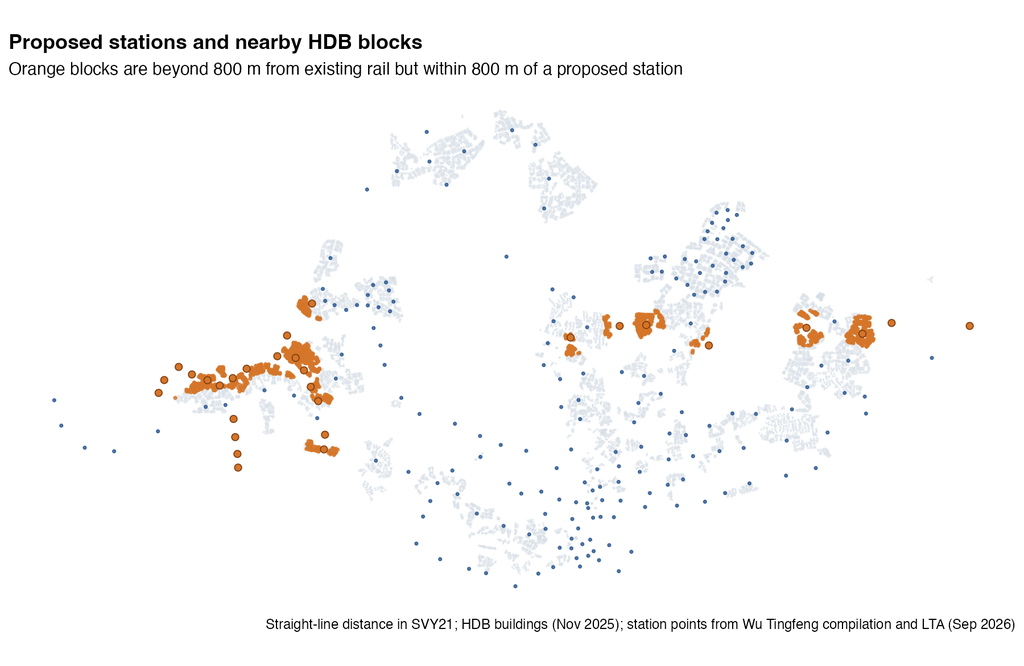

Map of proposed stations and HDB blocks newly within 800 metres of rail

Of **13,436 HDB blocks**, **9,676** lie within 800 m of current rail. The proposed locations bring **1,319 more** inside that straight-line threshold. The clusters sit mainly in the west and north-east.

## Fitting station choice

Each current origin contributes its observed outbound trips. A destination’s score uses nearby **HDB blocks**, **activity-zoned land**, **rail-line count**, **LRT-only status**, and **straight-line distance**. The scores become probabilities across all available destinations, including pairs with zero observed trips.

This generalised **Huff/MCI model** is fitted to observed OD flows. **36 origins** are held out to test prediction against a distance-only version.

## The fit limits the claim

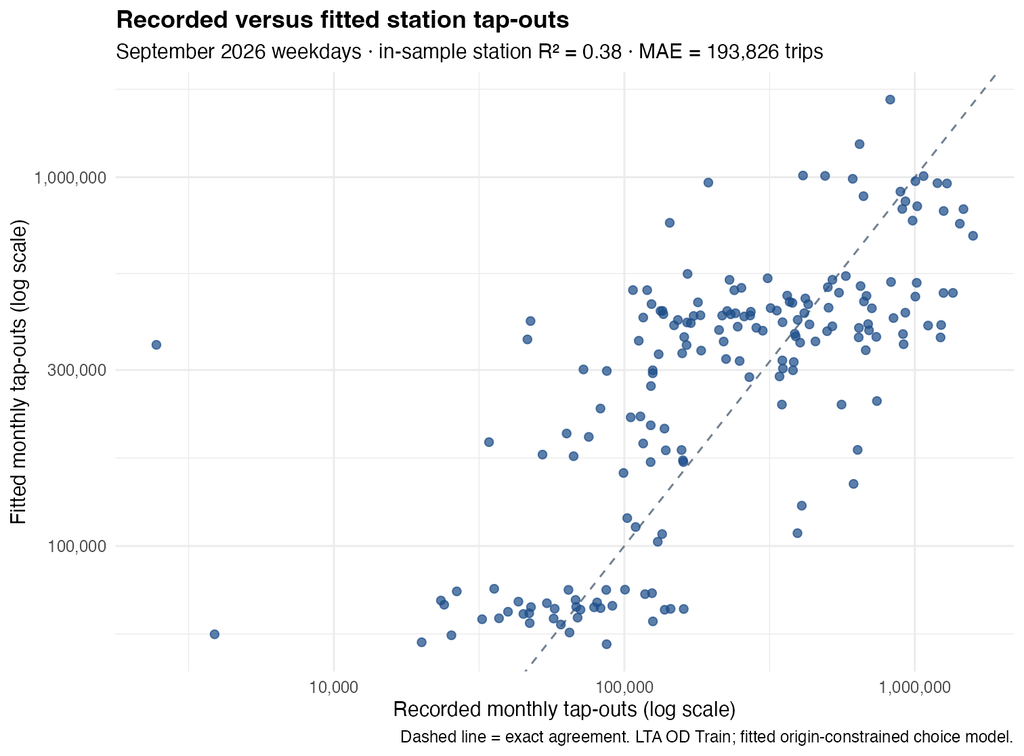

Scatterplot of recorded versus fitted station tap-outs, with wide errors around the equality line

Full-month station error averages **193,826 trips**; in-sample station R² is **0.38**. On held-out origins, the station MAE is **44,604**, versus **63,740** for distance only. The model improves, but many station totals remain far from observed counts.

## The new-station test fails

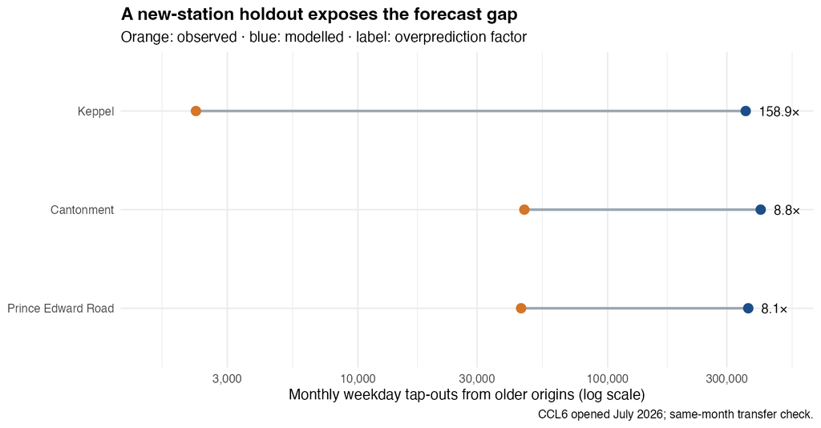

Observed and modelled tap-outs at three recently opened stations; all three are strongly overpredicted

Fitted without three stations opened in July 2026, the model overpredicts their September tap-outs by **8–159 times**. This is a same-month transfer check, yet it is a strong warning against treating proposed-station allocations as opening forecasts.

## New destinations in the fixed market

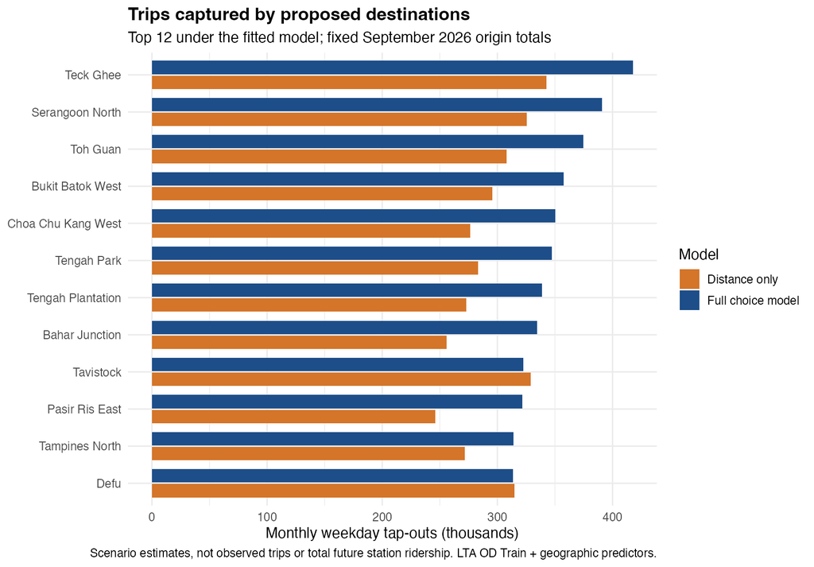

Top proposed-station allocations under the full and distance-only models

The fitted model allocates **7.55 million trips** to new destinations, about **11.3%** of current-origin trips. Distance only allocates **7.59 million** overall, but individual station allocations can differ substantially. These are conditional model outputs, not opening forecasts.

## Existing stations: a fragile interchange gain

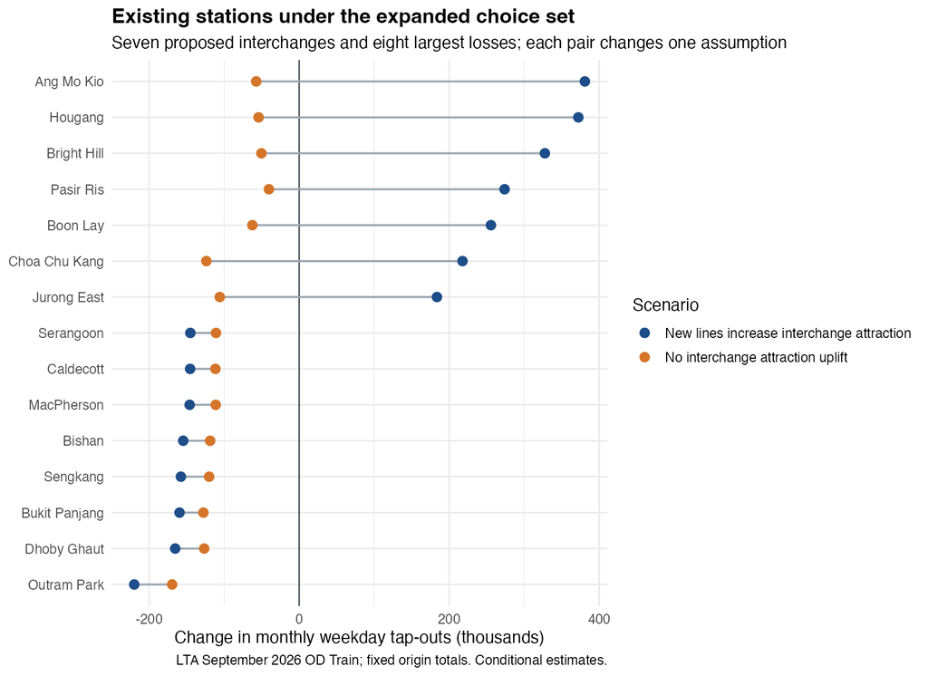

Changes at existing stations with and without an attraction uplift at seven proposed interchanges

Seven existing interchanges gain share in the main model because the added line raises their attraction score. **All seven lose share** if that uplift is removed. The direction of their change depends on this assumption.

## What the results support

The **1,319 newly reached HDB blocks** show a geographic access opportunity, subject to actual walking routes and block populations.

The **7.55 million allocated trips** show what the model does when new destinations enter a fixed September 2026 market. The failed new-station test and interchange sensitivity rule out treating that allocation as a planning forecast.

Check station entrances, road crossings and accessible walking routes before treating the mapped blocks as safely connected to rail. Capacity and crowd-management decisions need peak-hour flows and operational checks.